# L’intention de se vacciner - un pre-test dans une population de master 1

## Un modèle de régression général

```r
fit<- lm(Attitude~ConfianceG+Norme+risquepercu+ Impact+ GravitéPercue+Bieninformé+Gestion+Impactgrav+Age+Diplome+Sexe, data=df2)
summ(fit)
```

| Observations | 229 (10 missing obs. deleted) |
| --- | --- |
| Dependent variable | Attitude |
| Type | OLS linear regression |

| F(15,213) | 23.04 |
| --- | --- |
| R² | 0.62 |
| Adj. R² | 0.59 |

|  | Est. | S.E. | t val. | p |
| --- | --- | --- | --- | --- |
| (Intercept) | 3.76 | 2.51 | 1.50 | 0.14 |
| ConfianceG | 0.16 | 0.05 | 3.54 | 0.00 |
| Norme | 0.17 | 0.06 | 2.90 | 0.00 |
| risquepercu | -1.24 | 0.12 | -10.53 | 0.00 |
| Impact | 0.21 | 0.08 | 2.74 | 0.01 |
| GravitéPercue | -0.04 | 0.17 | -0.23 | 0.82 |
| Bieninformé | 0.11 | 0.12 | 0.93 | 0.36 |
| Gestion | 0.10 | 0.05 | 1.91 | 0.06 |
| Impactgrav | 0.06 | 0.24 | 0.24 | 0.81 |
| Age20-29 ans | 0.58 | 1.50 | 0.38 | 0.70 |
| Age30-39 ans | -0.79 | 1.73 | -0.46 | 0.65 |
| Age40-55 ans | 2.97 | 1.54 | 1.93 | 0.05 |
| Age56- 65 ans | 4.77 | 1.86 | 2.57 | 0.01 |
| DiplomeLicence | -0.84 | 0.98 | -0.85 | 0.40 |
| DiplomeMaster | -0.53 | 0.99 | -0.54 | 0.59 |
| SexeHomme | 1.27 | 0.71 | 1.78 | 0.08 |

Standard errors: OLS

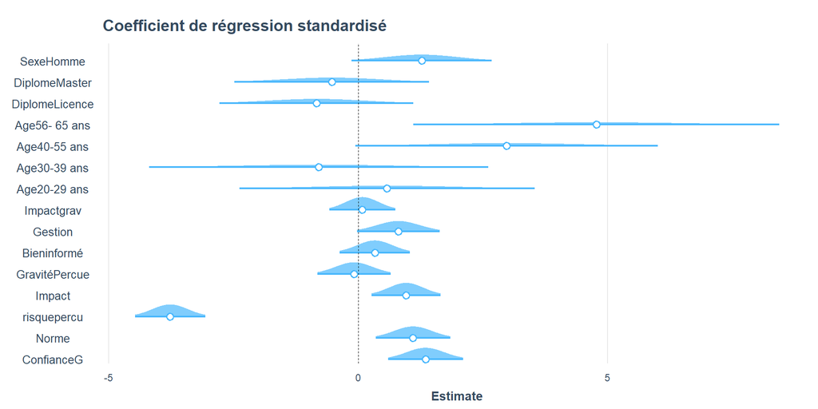

```r
plot_summs(fit, scale=TRUE,plot.distributions=TRUE)+labs(title="Coefficient de régression standardisé")
```

```r
ggsave("conf04.jpeg",plot=last_plot(), width = 18, height = 14, units = "cm")
```

## Une exploration ar les corrélation partielles

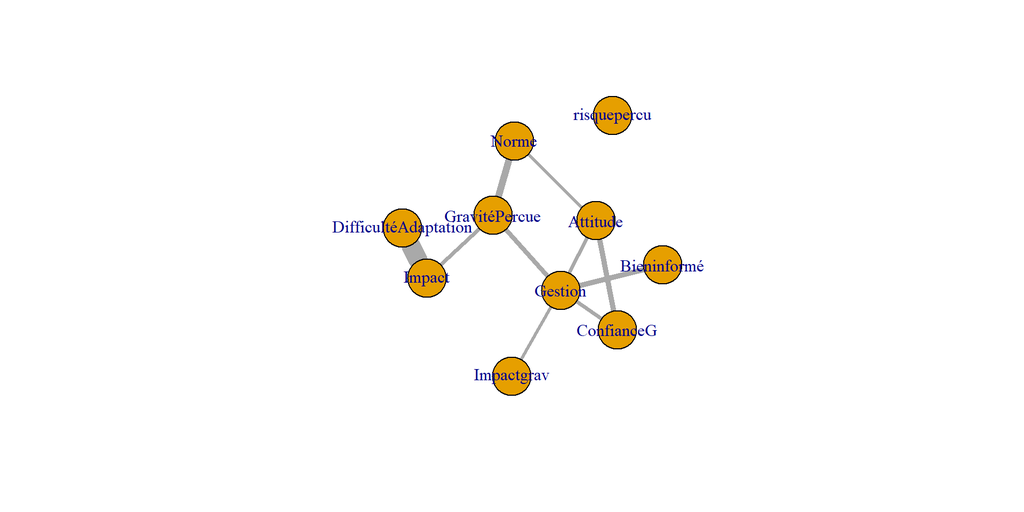

```r
x<-df2%>%dplyr::select(Attitude,ConfianceG,Norme,Impactgrav, risquepercu, Impact, GravitéPercue,DifficultéAdaptation, Bieninformé,Gestion)%>%drop_na()
x$Impactgrav<-as.numeric(x$Impactgrav)

r<- cor(x)
pr<-pcor(x)
pr<-pr$estimate
names<-row.names(r)
colnames(pr)<-names

graph <- graph.adjacency(pr, weighted=TRUE, mode="upper")
graph <- delete.edges(graph, E(graph)[ weight < 0.15 ])
graph<-simplify(graph)
E(graph)$width <-E(graph)$weight*20
plot(graph,vertex.size=30)
```

## Un modèle structurel ( path analysis)

C’est un système d’équations structurelles - sans variable latente - dans lequel il y a trois variables purement exogènes :

- la confiance sociale (score des confiances envers les 17 institutions)
- l’adhésion aux normes sanitaires (score des gestes barrières)
- l’expérience direct ou non du covid.

Les deux variables endogènes sont l’attitude face à la vaccination (intention +recommendation) et le jugement sur les politiques sanitaires. Ce dernier affectant l’attitude envers les vaccins.

Les variables médiatrices sont d’une part le sentiment d’être bien informé et le degré avec lequel la vie est perturbée par l’épidémie et ses conséquences.

L’attitude favorable au vaccin dépend surtout de la perception du risque, puis de l’intégration sociale et enfin dans une plus faible mesure du jugement sur les politiques sanitaires. La perception du risque dépend fortement de la confiance sociale mais aussi du sentiment d’adaptation à la situation. Ni l’expérience directe du covid , ni la perception de la gravité de la situation.

On sera surpris que ni la proximité au covid, ni même le jugement de gravité de l’épidémie ne compte dans la décision. Ce qui apparait déterminant est une sorte d’équilibre entre la confiance que l’on a dans les institutions de la société et le sentiment d’être déstabilisé, inadapté à la situation générées par l’épidémie et ses conséquences sanitaires.

```r
model <- ' # direct effect
             Attitude ~ ConfianceG+Norme +Gestion +risquepercu+Bieninformé
             Gestion~ConfianceG+Norme+DifficultéAdaptation+Bieninformé
             Impact~Impactgrav
             DifficultéAdaptation~Impact+Impactgrav
             risquepercu~ConfianceG+DifficultéAdaptation+Bieninformé
             GravitéPercue~Impact+DifficultéAdaptation
             Bieninformé~ConfianceG+Norme
          '
fit <- sem(model, data = x)
fitMeasures(fit, c("cfi","rmsea","srmr"))
```

```
##   cfi rmsea  srmr
## 0.904 0.127 0.110
```

```r
summary(fit)
```

```
## lavaan 0.6-7 ended normally after 48 iterations
##
##   Estimator                                         ML
##   Optimization method                           NLMINB
##   Number of free parameters                         27
##
##   Number of observations                           229
##
## Model Test User Model:
##
##   Test statistic                               103.506
##   Degrees of freedom                                22
##   P-value (Chi-square)                           0.000
##
## Parameter Estimates:
##
##   Standard errors                             Standard
##   Information                                 Expected
##   Information saturated (h1) model          Structured
##
## Regressions:
##                          Estimate  Std.Err  z-value  P(>|z|)
##   Attitude ~
##     ConfianceG              0.192    0.045    4.260    0.000
##     Norme                   0.137    0.054    2.545    0.011
##     Gestion                 0.106    0.046    2.285    0.022
##     risquepercu            -1.244    0.115  -10.814    0.000
##     Bieninformé             0.157    0.123    1.276    0.202
##   Gestion ~
##     ConfianceG              0.254    0.056    4.520    0.000
##     Norme                   0.299    0.071    4.178    0.000
##     DifficltAdpttn         -0.691    0.154   -4.496    0.000
##     Bieninformé             0.754    0.163    4.639    0.000
##   Impact ~
##     Impactgrav              0.278    0.216    1.289    0.197
##   DifficultéAdaptation ~
##     Impact                  0.571    0.017   34.197    0.000
##     Impactgrav             -0.032    0.055   -0.591    0.555
##   risquepercu ~
##     ConfianceG             -0.133    0.023   -5.838    0.000
```

[output cut: 8 more lines]

```
##
## Covariances:
##                    Estimate  Std.Err  z-value  P(>|z|)
##  .Attitude ~~
##    .GravitéPercue     0.386    0.697    0.554    0.580
##
## Variances:
##                    Estimate  Std.Err  z-value  P(>|z|)
##    .Attitude         23.967    2.240   10.700    0.000
##    .Gestion          45.138    4.218   10.700    0.000
##    .Impact           21.356    1.996   10.700    0.000
##    .DifficltAdpttn    1.363    0.127   10.700    0.000
##    .risquepercu       7.707    0.720   10.700    0.000
##    .GravitéPercue     4.639    0.434   10.700    0.000
##    .Bieninformé       7.464    0.698   10.700    0.000
```

```r
#semPaths(fit, intercepts = F, nodeLabels = 1:9)


lbls <- c("Attitude\nvaccins",
          "Politique\nSanitaire ",
          "Impact sur la \nvie personnelle",
          "Difficultés\nd'adaptation",
          "Risque perçu\ndes vaccins",
          "Gravité perçue",
          "être bien\ninformé",
          "Confiance\nSociale",
          "Adhésion\n aux normes",
          "Contact avec \n le Covid19")

ly <- matrix(c(-.5, -.75,
               .5, -.75,
               0.4, .5,
               0.35, -.15,
               -0.15, -0.15,
               0, 0.5,
               -.5, 0.5,
               -0.5,1,
               0,1,
               .5,1), ncol = 2,
    byrow = TRUE)

p<-semPaths(fit,layout=ly,nCharNodes = 0,
         edge.color="black",what="std",
         exoCov  = TRUE,residuals=FALSE,
         sizeMan=12, sizeMan2=8,
         nodeLabels = lbls)
```

[figure not shown]

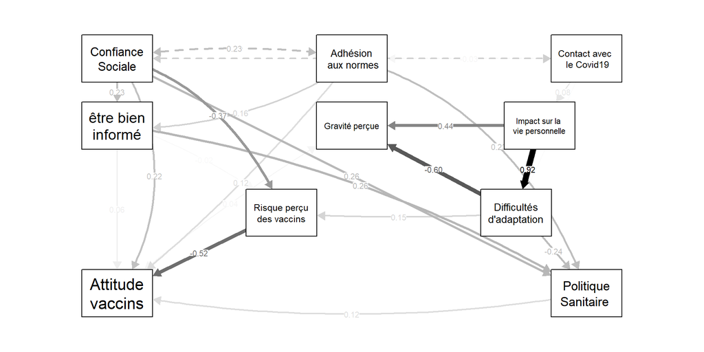

```r
p$graphAttributes$Edges$curve <- c(0.9, 0.2, 0.5, 0, 0, 0)
plot(p)
```